# *Haberman Cancer Survival Analysis*

### Creating dataframe "survival"

```python
import pandas as pd
import seaborn as sns
import matplotlib.pyplot as plt
import numpy as np

survival = pd.read_csv("haberman.csv")
```

```python
survival.columns = ['age','year','axil','expectancy']     #Assigning names to the columns
survival.head(5)
```

|  | age | year | axil | expectancy |
| --- | --- | --- | --- | --- |
| 0 | 30 | 62 | 3 | 1 |
| 1 | 30 | 65 | 0 | 1 |
| 2 | 31 | 59 | 2 | 1 |
| 3 | 31 | 65 | 4 | 1 |
| 4 | 33 | 58 | 10 | 1 |

## Additional Info:

### '1' Denotes the person survived for 5 years or more i.e Survived class

### '2' Denotes the person died withing 5 years of operation i.e Not survived Class

## Checking the number of entries of each class of the dataframe

```python
survival["expectancy"].value_counts()
```

```
1    224
2     81
dtype: int64
```

## Obeservation:

1. Imbalance dataset containing ~74% data of class 1.

# Univariate Analysis

### 1-D Scatter Plot (Feature : Number of Positive Axilliary Nodes)

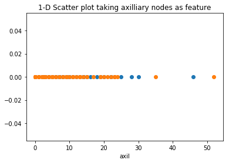

```python
import numpy as np
Yes = survival.loc[survival['expectancy'] == 1];
No = survival.loc[survival['expectancy'] == 2];

plt.plot(Yes["axil"], np.zeros_like(Yes['axil']), 'o')
plt.plot(No["axil"], np.zeros_like(No['axil']), 'o')
plt.xlabel("axil")
plt.title('1-D Scatter plot taking axilliary nodes as feature')
plt.show()
```

### Obeservation:

[output not shown]

### Probability Density Function (Number of Positive Axilliary nodes as feature)

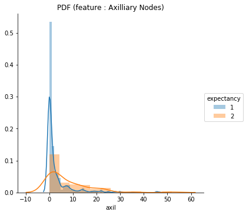

```python
sns.FacetGrid(survival, hue="expectancy", size=5) \
   .map(sns.distplot, "axil") \
   .add_legend();
plt.title("PDF (feature : Axilliary Nodes)")
plt.show()
```

### Obeservations:

```
1. Graph is higly overlaped, hence it can't classify the classes clearly.
2. Number of positive auxilliary nodes in the range 0 to 4 has more points belonging to '1'.
3. Number of positive auxilliary nodes in range 4 to 30 has more points belonging to '2'.
4. Maximum number class '1' points occurs when no Positive Auxilliary Nodes found.
```

### Plotting CDF (For survived class)

```
[0.83482143 0.08035714 0.02232143 0.02678571 0.01785714 0.00446429
 0.00892857 0.         0.         0.00446429]
[ 0.   4.6  9.2 13.8 18.4 23.  27.6 32.2 36.8 41.4 46. ]
```

```
Text(0.5,0,'axil')
```

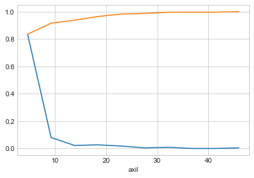

```python
#Person Survived
counts, bin_edges = np.histogram(Yes['axil'], bins=10,
                                 density = True)
pdf = counts/(sum(counts))
print(pdf);
print(bin_edges)
cdf = np.cumsum(pdf)
plt.plot(bin_edges[1:],pdf)
plt.plot(bin_edges[1:], cdf)
plt.xlabel("axil")
```

### Obeservation:

```
1. We can't draw any exact conclusions or if else module from this CDF plot.
```

### Plotting CDF (For not survived class)

```
[0.56790123 0.14814815 0.13580247 0.04938272 0.07407407 0.
 0.01234568 0.         0.         0.01234568]
[ 0.   5.2 10.4 15.6 20.8 26.  31.2 36.4 41.6 46.8 52. ]
```

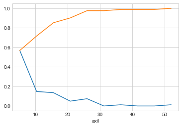

```python
# Person not survived
counts, bin_edges = np.histogram(No['axil'], bins=10,
                                 density = True)
pdf = counts/(sum(counts))
print(pdf);
print(bin_edges)
cdf = np.cumsum(pdf)
plt.plot(bin_edges[1:],pdf)
plt.xlabel("axil")
plt.plot(bin_edges[1:], cdf)
```

### Obeservation:

1. We can't draw any exact conclusion from this graph.

### 1-D Scatter Plot (Feature : Age of Patient)

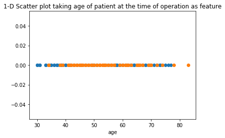

```python
import numpy as np
Yes = survival.loc[survival['expectancy'] == 1];
No = survival.loc[survival['expectancy'] == 2];
plt.xlabel("age")
plt.title('1-D Scatter plot taking age of patient at the time of operation as feature')
plt.plot(Yes["age"], np.zeros_like(Yes['age']), 'o')
plt.plot(No["age"], np.zeros_like(No['age']), 'o')
plt.show()
```

### Obeservations:

1. Using age, we can somehow distinguish the two classes.
2. Age of range 40 - ~62 has more points belonging to survived class.

### Probability Density Function (Age of Patient as feature)

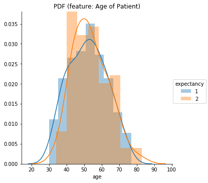

```python
sns.FacetGrid(survival, hue="expectancy", size=5) \
   .map(sns.distplot, "age") \
   .add_legend();
plt.title("PDF (feature: Age of Patient)")
plt.show();
```

### Obeservations:

1.Graph is higly overlaped, hence it can't distinguish the classes clearly.

### Plotting CDF (For Survived class)

```
[0.04910714 0.10714286 0.125      0.09375    0.16517857 0.16517857
 0.09375    0.11160714 0.0625     0.02678571]
[30.  34.7 39.4 44.1 48.8 53.5 58.2 62.9 67.6 72.3 77. ]
```

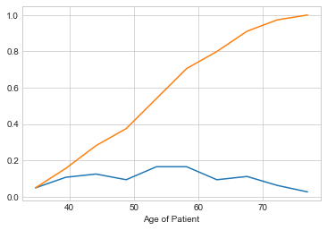

```python
counts, bin_edges = np.histogram(Yes['age'], bins=10,
                                 density = True)
pdf = counts/(sum(counts))
print(pdf);
print(bin_edges)
cdf = np.cumsum(pdf)
plt.plot(bin_edges[1:],pdf)
plt.xlabel("Age of Patient")
plt.plot(bin_edges[1:], cdf)
```

### Obeservations:

1.We can't draw any exact conclusion from this graph.

### Plotting CDF (For Not Survived class)

```
[0.03703704 0.12345679 0.19753086 0.19753086 0.13580247 0.12345679
 0.09876543 0.04938272 0.02469136 0.01234568]
[34.  38.9 43.8 48.7 53.6 58.5 63.4 68.3 73.2 78.1 83. ]
```

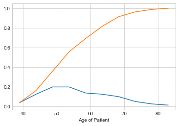

```python
counts, bin_edges = np.histogram(No['age'], bins=10,
                                 density = True)
pdf = counts/(sum(counts))
print(pdf);
print(bin_edges)
cdf = np.cumsum(pdf)
plt.plot(bin_edges[1:],pdf)
plt.xlabel("Age of Patient")
plt.plot(bin_edges[1:], cdf)
```

### Obeservations:

1.We can't draw any exact conclusion from this graph.

## Bi-variate Analysis

### 2-D Scatter plt (features: axil and age)

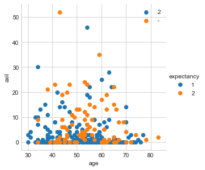

```python
sns.set_style("whitegrid");
sns.FacetGrid(survival, hue="expectancy", size=4) \
   .map(plt.scatter, "age", "axil") \
   .add_legend();
plt.legend("2-D Scatter plot (X-axis: age, Y-axis:axilliary nodes")
plt.show();
```

### 2-D Scatter plt (features: year and axil)

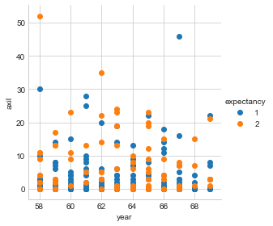

```python
sns.set_style("whitegrid");
sns.FacetGrid(survival, hue="expectancy", size=4) \
   .map(plt.scatter, "year", "axil") \
   .add_legend();
plt.show();
```

### 2-D Scatter plt (features: year and age)

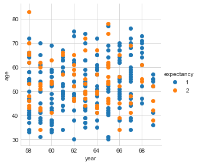

```python
sns.set_style("whitegrid");
sns.FacetGrid(survival, hue="expectancy", size=4) \
   .map(plt.scatter, "year", "age") \
   .add_legend();
plt.show()
```

### Obeservation:

1. These plots are not much informative as point are very overlaped and not linearly separable.

## 2-D Pair Plots

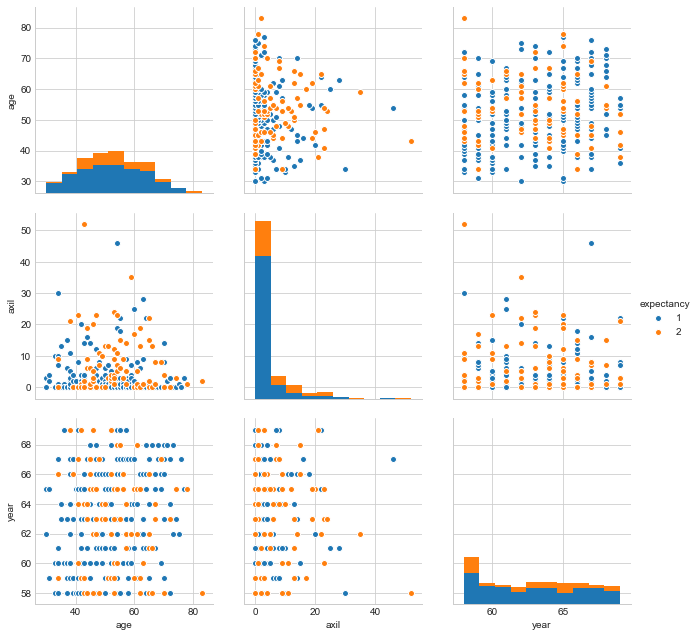

```python
plt.close();
sns.set_style("whitegrid");
sns.pairplot(survival, hue="expectancy", size=3, vars=("age","axil","year"));
plt.show()
```

## Obeservations:

#### 1.These plots are not much informative as point are very overlaped and not linearly separable.

#### 2.We can't find "lines" and "if-else" conditions to build a simple model to classify the classes.

## Median, Quantiles and 90th percentile (Feature: Axilliary nodes)

```python
print("\nMedians:")
print(np.median(Yes["axil"]))
print(np.median(No["axil"]))

print("\nQuantiles:")
print(np.percentile(Yes["axil"],np.arange(0, 100, 25)))
print(np.percentile(No["axil"],np.arange(0, 100, 25)))

print("\n90th Percentiles:")
print(np.percentile(Yes["axil"],90))
print(np.percentile(No["axil"],90))
```

```
Medians:
0.0
4.0

Quantiles:
[0. 0. 0. 3.]
[ 0.  1.  4. 11.]

90th Percentiles:
8.0
20.0
```

## Median, Quantile and 90th Percentile (Feature : Patient's Age)

```python
print("\nMedians:")
print(np.median(Yes["age"]))
print(np.median(No["age"]))

print("\nQuantiles:")
print(np.percentile(Yes["age"],np.arange(0, 100, 25)))
print(np.percentile(No["age"],np.arange(0, 100, 25)))

print("\n90th Percentiles:")
print(np.percentile(Yes["age"],90))
print(np.percentile(No["age"],90))
```

```
Medians:
52.0
53.0

Quantiles:
[30. 43. 52. 60.]
[34. 46. 53. 61.]

90th Percentiles:
67.0
67.0
```

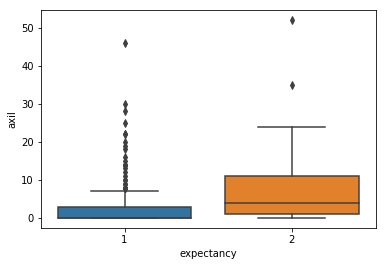

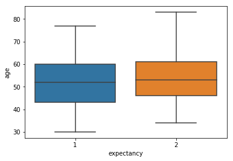

```python
#Box plot (feature: Number of positive axilliary node)

sns.boxplot(x='expectancy',y='axil', data=survival)
plt.show()

sns.boxplot(x='expectancy',y='age', data=survival)
plt.show()

'''
Obeservation :
   1. axil>0.5 belongs to not survived class.
'''
```

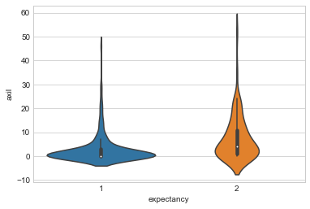

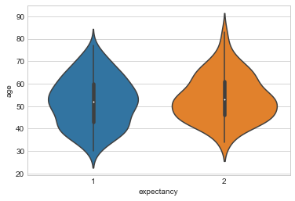

```python
#Voilin Plot
sns.violinplot(x="expectancy", y="axil", data=survival, size=8)
plt.show()

sns.violinplot(x="expectancy", y="age", data=survival, size=8)
plt.show()
```

## Multivariate probability density, contour plot.

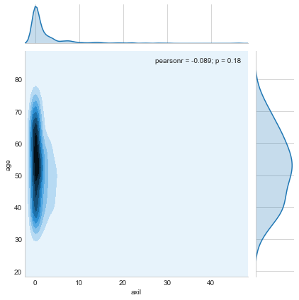

```python
sns.jointplot(x="axil", y="age", data=Yes, kind="kde");
plt.show();
```

### Obeservation:

1. At age of range 42 to 65 and having 0 positive axilliary nodes has huge desity of survived people.

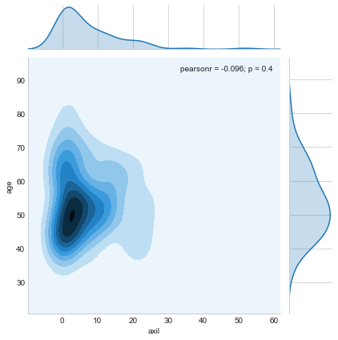

```python
sns.jointplot(x="axil", y="age", data=No, kind="kde");
plt.show();
```

### Obeservation:

1. Small number of people of age of 48 to 51 and number of axiliary having nodes between 2 to 4 are not survived people

# Conclusions:

### 1. The given data contains ~74% data of the patient survived.

### 2. The dataset is not linearly separable.

### 3. Graphs are higly overlaped, hence we cannot classify the classes perfectly.

### 4. The number of positive axilliary nodes is the most important feature.

### 5. Number of positive auxilliary nodes in the range 0 to 4 has more points belonging to '1'.

### 6. Number of positive auxilliary nodes in range 4 to 30 has more points belonging to '2'.

### 7. Maximum class '1' points occurs when no Positive Auxilliary Nodes found.

### 8. Person of Age(when they were operated) of range 40 to ~65 has survived the most.